# Taller: Modelo de Regresión Logística

Consumo Energético – Universidad Surcolombiana (USCO) – Especialización en Estadística

Author

Sergio Andres Beltran, Juan Pablo Donato

Published

April 24, 2026

# 1 Descripción del Problema e Hipótesis

La Sede Central de la Universidad Surcolombiana (USCO) cuenta con **cinco cuentas eléctricas activas** (Central 1 a Central 5). La normativa eléctrica colombiana (CREG 015 de 2018) establece que la relación entre energía reactiva y energía activa **no debe superar 0.48**. El incumplimiento de esta norma genera recargos económicos directos en la factura eléctrica.

El análisis se aborda en dos niveles:

- **Nivel Sede:** ¿El consumo total de energía activa de la sede predice si alguna cuenta incumplirá la norma ese mes?
- **Nivel Cuenta:** ¿El consumo de energía activa de una cuenta individual predice si esa cuenta cumplirá o no la norma?

**NoteHipótesis del Estudio**

**Modelo Simple — Nivel Sede:**

- $H_0: \beta_1 = 0$ → La energía activa total NO predice el incumplimiento normativo de la sede.
- $H_1: \beta_1 \neq 0$ → La energía activa total SÍ predice el incumplimiento normativo.

**Modelo Múltiple — Nivel Sede:**

- $H_0: \beta_1 = \beta_2 = 0$ → Ni la energía activa total ni el período de vacaciones académicas explican el incumplimiento normativo de la sede.
- $H_1$: Al menos un $\beta_k \neq 0$ → Alguna variable predice el incumplimiento.

**Modelos por Cuenta Individual:**

- $H_0: \beta_1 = 0$ → El consumo activo de la cuenta NO predice su propio cumplimiento.
- $H_1: \beta_1 \neq 0$ → El consumo activo SÍ predice el cumplimiento de la cuenta.

# 2 Descripción de Variables

**Ver código**

```r
# Definición de directorios y carga de fuentes de datos
RUTA_BASE <- "C:/Users/ESTUDIANTES/Documents/Working Holydays/"

# ── Carga de las dos tablas exportadas por el script de unificación ─────────────
dt_cuenta <- read.csv(paste0(RUTA_BASE, "Consumo_Central.csv"),
                      header = TRUE, sep = ",")
dt_sede   <- read.csv(paste0(RUTA_BASE, "Resumen_Sede.csv"),
                      header = TRUE, sep = ",")

# ── Conversiones de tipo necesarias para los modelos ─────────────────────────
dt_cuenta$Cuenta       <- factor(dt_cuenta$Cuenta)
dt_cuenta$Nombre_Cuenta<- factor(dt_cuenta$Nombre_Cuenta)
dt_cuenta$Cumple       <- factor(dt_cuenta$Cumple, levels = c("Sí", "No"))


dt_sede$Sede_Incumple  <- as.integer(dt_sede$Sede_Incumple)

# ── Tabla resumen de datos cargados ─────────────────────────────────────
resumen_datos <- data.frame(
  Concepto = c("Registros cuenta-período (Tabla 1)",
               "Registros sede-período (Tabla 2)",
               "Cuentas activas",
               "Período cubierto",
               "Períodos con incumplimiento (sede)"),
  Valor = c(as.character(nrow(dt_cuenta)),
            as.character(nrow(dt_sede)),
            as.character(length(unique(dt_cuenta$Cuenta))),
            paste(min(dt_cuenta$Ano), "–", max(dt_cuenta$Ano)),
            as.character(sum(dt_sede$Sede_Incumple)))
)

apa_table(resumen_datos,
          col.names = c("Concepto", "Valor"),
          caption   = "Resumen de los Datos Cargados",
          align     = c("l", "r"))
```

Resumen de los Datos Cargados

| Concepto | Valor |
| --- | --- |
| Registros cuenta-período (Tabla 1) | 1112 |
| Registros sede-período (Tabla 2) | 291 |
| Cuentas activas | 5 |
| Período cubierto | 2001 – 2025 |
| Períodos con incumplimiento (sede) | 142 |

**Ver código**

```r
apa_table(
  head(dt_cuenta[, c("Ano", "Mes", "Cuenta", "Nombre_Cuenta",
                     "Activa", "Reactiva", "Relacion", "Cumple", "Pago")], 8),
  caption = "Primeros 8 registros — Consumo por Cuenta (Tabla 1)",
  align   = c("c", "c", "c", "l", "r", "r", "r", "c", "r")
)
```

Primeros 8 registros — Consumo por Cuenta (Tabla 1)

| Ano | Mes | Cuenta | Nombre_Cuenta | Activa | Reactiva | Relacion | Cumple | Pago |
| --- | --- | --- | --- | --- | --- | --- | --- | --- |
| 2001 | 5 | 167382131 | Central 1 | 26000 | 960 | 0.0369231 | Sí | 5689170 |
| 2001 | 6 | 167382131 | Central 1 | 13840 | 160 | 0.0115607 | Sí | 3054810 |
| 2001 | 7 | 167382131 | Central 1 | 23520 | 400 | 0.0170068 | Sí | 5378590 |
| 2001 | 8 | 167382131 | Central 1 | 22960 | 640 | 0.0278746 | Sí | 5263020 |
| 2001 | 9 | 167382131 | Central 1 | 27600 | 1200 | 0.0434783 | Sí | 6507590 |
| 2001 | 10 | 167382131 | Central 1 | 23840 | 720 | 0.0302013 | Sí | 5639490 |
| 2001 | 11 | 167382131 | Central 1 | 22000 | 1040 | 0.0472727 | Sí | 4978020 |
| 2001 | 12 | 167382131 | Central 1 | 16480 | 560 | 0.0339806 | Sí | 3663650 |

**Ver código**

```r
apa_table(
  head(dt_sede[, c("Ano", "Mes", "Tiempo", "Activa_Total",
                   "Cuentas_Pagadas", "Cuentas_Incumplen", "Sede_Incumple")], 8),
  caption = "Primeros 8 registros — Resumen Sede (Tabla 2)",
  align   = c("c", "c", "c", "r", "c", "c", "c")
)
```

Primeros 8 registros — Resumen Sede (Tabla 2)

| Ano | Mes | Tiempo | Activa_Total | Cuentas_Pagadas | Cuentas_Incumplen | Sede_Incumple |
| --- | --- | --- | --- | --- | --- | --- |
| 2001 | 5 | 1 | 110240 | 3 | 2 | 1 |
| 2001 | 6 | 2 | 59080 | 3 | 1 | 1 |
| 2001 | 7 | 3 | 98400 | 3 | 1 | 1 |
| 2001 | 8 | 4 | 103720 | 3 | 0 | 0 |
| 2001 | 9 | 5 | 125360 | 3 | 0 | 0 |
| 2001 | 10 | 6 | 100560 | 3 | 1 | 1 |
| 2001 | 11 | 7 | 104320 | 3 | 0 | 0 |
| 2001 | 12 | 8 | 62000 | 3 | 0 | 0 |

**Ver código**

```r
tabla_vars <- data.frame(
  Tabla     = c("Tabla 2", "Tabla 2", "Tabla 2",
                "Tabla 1", "Tabla 1", "Tabla 1", "Tabla 1"),
  Variable  = c("Sede_Incumple", "Activa_Total", "Cuentas_Incumplen",
                "Cumple_bin", "Activa", "Cuenta", "Pago"),
  Tipo      = c("Binaria (0/1)", "Continua", "Discreta (0–5)",
                "Binaria (0/1)", "Continua", "Categórica (5 niveles)", "Continua"),
  Rol       = c("**Y — Modelo Sede**", "X principal — Modelo Sede",
                "Descriptiva",
                "**Y — Modelo Central 2** (Sección 6.5)", "X principal — Modelo Cuenta",
                "Covariable — Modelo Unificado", "Descriptiva"),
  Descripcion = c(
    "1 = al menos una cuenta incumple ese mes; 0 = todas cumplen",
    "Suma de energía activa de las 5 cuentas (kWh)",
    "Número de cuentas con Reactiva/Activa > 0.48 ese mes",
    "1 = cuenta cumple norma ese mes; 0 = incumple",
    "Energía activa individual de la cuenta (kWh)",
    "Identificador de cuenta (Central 1 a Central 5)",
    "Valor pagado por la cuenta ese período (COP)"
  )
)

apa_table(tabla_vars,
         col.names = c("Tabla", "Variable", "Tipo", "Rol", "Descripción"),
         caption   = "Diccionario de Variables del Estudio",
         align     = c("l", "l", "l", "l", "l"))
```

Diccionario de Variables del Estudio

[output not shown]

**WarningVariables excluidas del modelo — Razón metodológica**

**`Relacion`** y **`Reactiva`** no se incluyen como predictoras porque `Cumple` se define directamente como `Relacion ≤ 0.48`, donde `Relacion = Reactiva / Activa`. Incluirlas sería tautológico: el modelo estaría explicando Y con la misma información usada para construir Y, generando coeficientes artificialmente perfectos sin valor predictivo real.

# 3 Exploración de Datos

## 3.1 Distribución del Cumplimiento Normativo

**Ver código**

```r
# ── Período máximo de referencia ──────────────────────────────────────────────
periodo_max <- max(dt_cuenta$Tiempo, na.rm = TRUE)  # 291

# ── Tabla EPV por cuenta con cobertura temporal ──────────────────────────────
epv_tabla <- dt_cuenta %>%
  group_by(Cuenta, Nombre_Cuenta) %>%
  summarise(
    Inicio      = min(Tiempo, na.rm = TRUE),
    Períodos    = n(),
    Esperados   = periodo_max - Inicio + 1,
    Faltantes   = Esperados - Períodos,
    Cumple    = sum(Cumple == "Sí", na.rm = TRUE),
    No_Cumple = Períodos - Cumple,
    Pct_Cumple  = round(Cumple  / Períodos * 100, 1),
    EPV_max_vars = floor(No_Cumple / 10),
    .groups = "drop"
  )

# ── Fila resumen sede ─────────────────────────────────────────────────────────
epv_sede <- dt_sede %>%
  summarise(
    Inicio       = min(Tiempo, na.rm = TRUE),
    Períodos     = n(),
    Esperados    = periodo_max - Inicio + 1,
    Faltantes    = Esperados - Períodos,
    Cumple       = sum(Sede_Incumple == 0),
    No_Cumple    = sum(Sede_Incumple == 1),
    Pct_Cumple   = round(Cumple / Períodos * 100, 1),
    EPV_max_vars = floor(No_Cumple / 10)
  ) %>%
  mutate(Cuenta = "SEDE", Nombre_Cuenta = "Sede Central (todas)") %>%
  select(Cuenta, Nombre_Cuenta, everything())

epv_completa <- bind_rows(epv_tabla, epv_sede)

apa_table(epv_completa,
         col.names = c("Cuenta", "Nombre", "Inicio", "Períodos",
                       "Esperados", "Faltantes", "Cumple",
                       "Incumple", "% Cumple", "Máx. vars (EPV)"),
         caption   = "Distribución del Cumplimiento Normativo, Cobertura Temporal y Capacidad del Modelo (EPV)",
         align     = c("l", "l", "c", "c", "c", "c", "r", "r", "r", "c"),
         nota      = paste0("Inicio: período secuencial en que la cuenta registra su primera medición. ",
                            "Esperados: períodos desde el inicio hasta el período ", periodo_max,
                            ". Faltantes: períodos sin registro desde el inicio (huecos en la serie)."))
```

Distribución del Cumplimiento Normativo, Cobertura Temporal y Capacidad del Modelo (EPV)

| Cuenta | Nombre | Inicio | Períodos | Esperados | Faltantes | Cumple | Incumple | % Cumple | Máx. vars (EPV) |
| --- | --- | --- | --- | --- | --- | --- | --- | --- | --- |
| 167382131 | Central 1 | 1 | 286 | 291 | 5 | 282 | 4 | 98.6 | 0 |
| 167383918 | Central 4 | 1 | 277 | 291 | 14 | 274 | 3 | 98.9 | 0 |
| 167385482 | Central 2 | 1 | 286 | 291 | 5 | 147 | 139 | 51.4 | 13 |
| 357154485 | Central 5 | 32 | 239 | 260 | 21 | 215 | 24 | 90.0 | 2 |
| 847747377 | Central 3 | 265 | 24 | 27 | 3 | 17 | 7 | 70.8 | 0 |
| SEDE | Sede Central (todas) | 1 | 291 | 291 | 0 | 149 | 142 | 51.2 | 14 |

Nota. Inicio: período secuencial en que la cuenta registra su primera medición. Esperados: períodos desde el inicio hasta el período 291. Faltantes: períodos sin registro desde el inicio (huecos en la serie).

**NoteRegla de los 10 Eventos por Variable (EPV)**

## 3.2 Gráfico Principal: Pago, Cuentas Pagadas e Incumplimiento en el Tiempo

**Ver código**

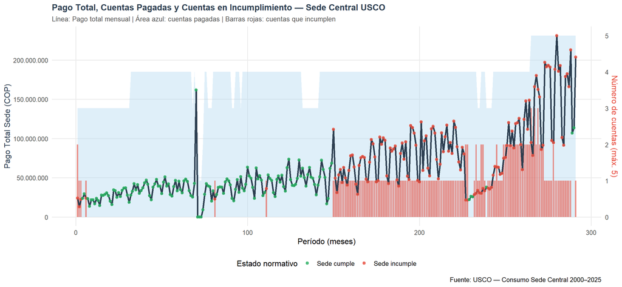

```r
# Escala de transformación para el eje secundario (0–5 → escala del pago)
pago_max  <- max(dt_sede$Pago_Total_Sede, na.rm = TRUE)
escala_k  <- pago_max / 5          # factor para llevar 0–5 a la escala del pago

ggplot(dt_sede, aes(x = Tiempo)) +

  # ── Área: Cuentas pagadas (fondo) ──────────────────────────────────────────
  geom_area(aes(y = Cuentas_Pagadas * escala_k),
            fill = "#AED6F1", alpha = 0.4) +

  # ── Barras: Cuentas que incumplen ──────────────────────────────────────────
  geom_col(aes(y = Cuentas_Incumplen * escala_k),
           fill  = "#E74C3C", alpha = 0.6, width = 0.8) +

  # ── Línea: Pago Total Sede ─────────────────────────────────────────────────
  geom_line(aes(y = Pago_Total_Sede),
            color = "#2C3E50", linewidth = 1.1) +
  geom_point(aes(y = Pago_Total_Sede,
                 color = factor(Sede_Incumple)),
             size = 1.8, alpha = 0.8) +
  scale_color_manual(
    values = c("0" = "#27AE60", "1" = "#E74C3C"),
    labels = c("0" = "Sede cumple", "1" = "Sede incumple"),
    name   = "Estado normativo"
  ) +

  # ── Eje secundario (derecho): escala 0–5 ──────────────────────────────────
  scale_y_continuous(
    name   = "Pago Total Sede (COP)",
    labels = label_comma(big.mark = ".", decimal.mark = ","),
    sec.axis = sec_axis(
      transform = ~ . / escala_k,
      name      = "Número de cuentas (máx. 5)",
      breaks    = 0:5
    )
  ) +

  labs(
    title    = "Pago Total, Cuentas Pagadas y Cuentas en Incumplimiento — Sede Central USCO",
    subtitle = "Línea: Pago total mensual | Área azul: cuentas pagadas | Barras rojas: cuentas que incumplen",
    x        = "Período (meses)",
    caption  = "Fuente: USCO — Consumo Sede Central 2000–2025"
  ) +
  theme_minimal(base_size = 12) +
  theme(
    plot.title       = element_text(face = "bold", color = "#2C3E50", size = 13),
    plot.subtitle    = element_text(color = "#555555", size = 10),
    axis.title.y     = element_text(color = "#2C3E50"),
    axis.title.y.right = element_text(color = "#E74C3C"),
    legend.position  = "bottom",
    panel.grid.minor = element_blank()
  )
```

**Interpretación:** Los períodos donde las barras rojas son más altas (más cuentas incumpliendo) tienden a coincidir visualmente con picos en el valor del pago, lo que sugiere que el incumplimiento normativo tiene un efecto económico observable. Esta relación motiva la construcción del modelo logístico.

## 3.3 Consumo Activo por Cuenta en el Tiempo

**Ver código**

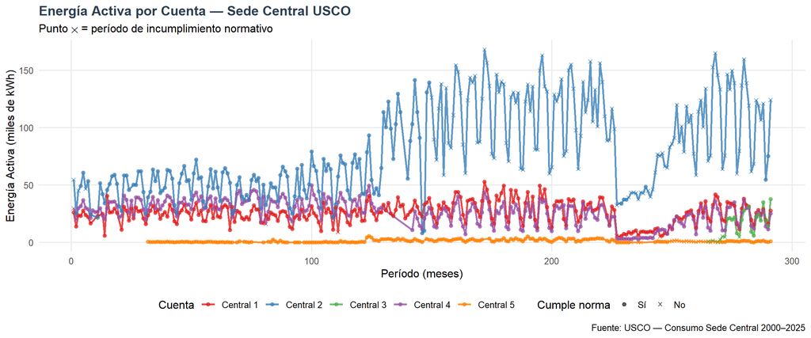

```r
ggplot(dt_cuenta, aes(x = Tiempo, y = Activa / 1000,
                       color = Nombre_Cuenta, group = Nombre_Cuenta)) +
  geom_line(alpha = 0.8, linewidth = 0.9) +
  geom_point(aes(shape = Cumple), size = 1.5, alpha = 0.6) +
  scale_shape_manual(values = c("Sí" = 19, "No" = 4),
                     name   = "Cumple norma") +
  scale_color_brewer(palette = "Set1", name = "Cuenta") +
  labs(
    title    = "Energía Activa por Cuenta — Sede Central USCO",
    subtitle = "Punto ✕ = período de incumplimiento normativo",
    x        = "Período (meses)",
    y        = "Energía Activa (miles de kWh)",
    caption  = "Fuente: USCO — Consumo Sede Central 2000–2025"
  ) +
  theme_minimal(base_size = 12) +
  theme(
    plot.title    = element_text(face = "bold", color = "#2C3E50"),
    legend.position = "bottom",
    panel.grid.minor = element_blank()
  )
```

# 4 Modelo Logístico Simple — Nivel Sede

**Variable Dependiente ($Y$):** `Sede_Incumple` (0 = todas cumplen, 1 = al menos una incumple) **Variable Predictora ($X$):** `Activa_Total` (kWh totales de la sede ese mes)

## 4.1 La Función Logística

El modelo no estima directamente si la sede incumplirá, sino la **probabilidad** de que ocurra el incumplimiento, acotada estrictamente entre 0 y 1 mediante la función sigmoide:

$$P(Sede\_Incumple = 1 \mid X) = \frac{1}{1 + e^{-(\beta_0 + \beta_1 \cdot Activa\_Total)}}$$

## 4.2 Estimación del Modelo

**Ver código**

```r
modelo_sede_simple <- glm(Sede_Incumple ~ Activa_Total,
                          data   = dt_sede,
                          family = binomial(link = "logit"))

resumen_s <- summary(modelo_sede_simple)
b0_s <- coef(modelo_sede_simple)[1]
b1_s <- coef(modelo_sede_simple)[2]

# ── Tabla de coeficientes ──────────────────────────────────────────────────────
coef_tabla_s <- data.frame(
  Parámetro   = c("β₀ (Intercepto)", "β₁ (Activa_Total)"),
  Estimador   = round(resumen_s$coefficients[, 1], 6),
  Error_Std   = round(resumen_s$coefficients[, 2], 6),
  z           = round(resumen_s$coefficients[, 3], 4),
  p_valor     = format(resumen_s$coefficients[, 4], scientific = TRUE)
)

apa_table(coef_tabla_s,
         col.names = c("Parámetro", "Estimador", "Error Estándar", "z", "p-valor"),
         caption   = "Coeficientes del Modelo Logístico Simple — Nivel Sede",
         align     = c("l", "r", "r", "r", "r"))
```

Coeficientes del Modelo Logístico Simple — Nivel Sede

| Parámetro | Estimador | Error Estándar | z | p-valor |
| --- | --- | --- | --- | --- |
| β₀ (Intercepto) | -2.535903 | 0.388575 | -6.5262 | 6.747827e-11 |
| β₁ (Activa_Total) | 0.000019 | 0.000003 | 6.6734 | 2.498793e-11 |

**Ver código**

```r
# ── Indicadores de ajuste ─────────────────────────────────────────────────────
ajuste_s <- data.frame(
  Indicador = c("Devianza nula", "Devianza residual", "AIC", "N observaciones"),
  Valor     = c(round(resumen_s$null.deviance, 2),
                round(resumen_s$deviance, 2),
                round(resumen_s$aic, 2),
                nrow(dt_sede))
)

apa_table(ajuste_s,
         col.names = c("Indicador", "Valor"),
         caption   = "Indicadores de Ajuste — Modelo Logístico Simple (Sede)",
         align     = c("l", "r"))
```

Indicadores de Ajuste — Modelo Logístico Simple (Sede)

| Indicador | Valor |
| --- | --- |
| Devianza nula | 403.24 |
| Devianza residual | 345.72 |
| AIC | 349.72 |
| N observaciones | 291.00 |

## 4.3 Ecuación del Modelo

**ImportantEcuación del Modelo Logístico Simple**

**Escala Log-Odds (Logit):**

$$\ln\left(\frac{P}{1-P}\right) = -2.5359 + 0.00001930 \cdot Activa\_Total$$

**Escala de Probabilidad (Sigmoide):**

$$P(Incumple) = \frac{1}{1 + e^{-(-2.5359 + 0.00001930 \cdot Activa\_Total)}}$$

**Interpretación del coeficiente $\beta_1$:**

- Por cada kWh adicional de Activa_Total, el log-odds de incumplimiento cambia en 0.00001930 unidades.
- En términos del **Odds Ratio**: $OR = e^{\beta_1} = e^{0.00001930} = 1.000019$

## 4.4 Interpretación: Odds Ratios e Intervalos de Confianza

**Ver código**

```r
or_sede_s <- exp(cbind(OR = coef(modelo_sede_simple),
                        confint(modelo_sede_simple)))

or_tabla <- as.data.frame(round(or_sede_s, 6))
or_tabla$Variable    <- rownames(or_tabla)
or_tabla$Significativo <- c("—",
  ifelse(resumen_s$coefficients[2, 4] < 0.05, "✓ Sí (p < 0.05)", "✗ No"))
or_tabla$Interpretacion <- c(
  "Punto de anclaje matemático",
  ifelse(exp(b1_s) > 1,
         "Factor de RIESGO: mayor activa → mayor prob. de incumplir",
         "Factor PROTECTOR: mayor activa → menor prob. de incumplir")
)

apa_table(or_tabla[, c("Variable", "OR", "2.5 %", "97.5 %",
                       "Significativo", "Interpretacion")],
         col.names = c("Variable", "OR", "IC 2.5%", "IC 97.5%",
                       "Significativo", "Interpretación"),
         caption   = "Odds Ratios — Modelo Logístico Simple (Sede)",
         align     = c("l", "r", "r", "r", "c", "l"))
```

Odds Ratios — Modelo Logístico Simple (Sede)

| Variable | OR | IC 2.5% | IC 97.5% | Significativo | Interpretación |
| --- | --- | --- | --- | --- | --- |
| (Intercept) | 0.079190 | 0.035904 | 0.165371 | — | Punto de anclaje matemático |
| Activa_Total | 1.000019 | 1.000014 | 1.000025 | ✓ Sí (p < 0.05) | Factor de RIESGO: mayor activa → mayor prob. de incumplir |

## 4.5 Curva Logística Ajustada

**Ver código**

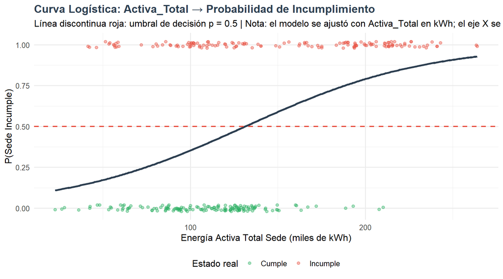

```r
rango_activa <- data.frame(
  Activa_Total = seq(min(dt_sede$Activa_Total, na.rm = TRUE),
                     max(dt_sede$Activa_Total, na.rm = TRUE),
                     length.out = 300)
)
rango_activa$Prob <- predict(modelo_sede_simple,
                              newdata = rango_activa, type = "response")

ggplot() +
  geom_jitter(data = dt_sede,
              aes(x = Activa_Total / 1000, y = Sede_Incumple,
                  color = factor(Sede_Incumple)),
              height = 0.02, alpha = 0.4, size = 1.5) +
  geom_line(data = rango_activa,
            aes(x = Activa_Total / 1000, y = Prob),
            color = "#2C3E50", linewidth = 1.4) +
  geom_hline(yintercept = 0.5, color = "#E74C3C",
             linetype = "dashed", linewidth = 0.8) +
  scale_color_manual(values = c("0" = "#27AE60", "1" = "#E74C3C"),
                     labels = c("0" = "Cumple", "1" = "Incumple"),
                     name   = "Estado real") +
  labs(
    title    = "Curva Logística: Activa_Total → Probabilidad de Incumplimiento",
    subtitle = paste0("Línea discontinua roja: umbral de decisión p = 0.5",
                     " | Nota: el modelo se ajustó con Activa_Total en kWh;",
                     " el eje X se muestra en MWh para legibilidad"),
    x        = "Energía Activa Total Sede (miles de kWh)",
    y        = "P(Sede Incumple)"
  ) +
  theme_minimal(base_size = 12) +
  theme(plot.title = element_text(face = "bold", color = "#2C3E50"),
        legend.position = "bottom")
```

## 4.6 Matriz de Confusión y Métricas

**Ver código**

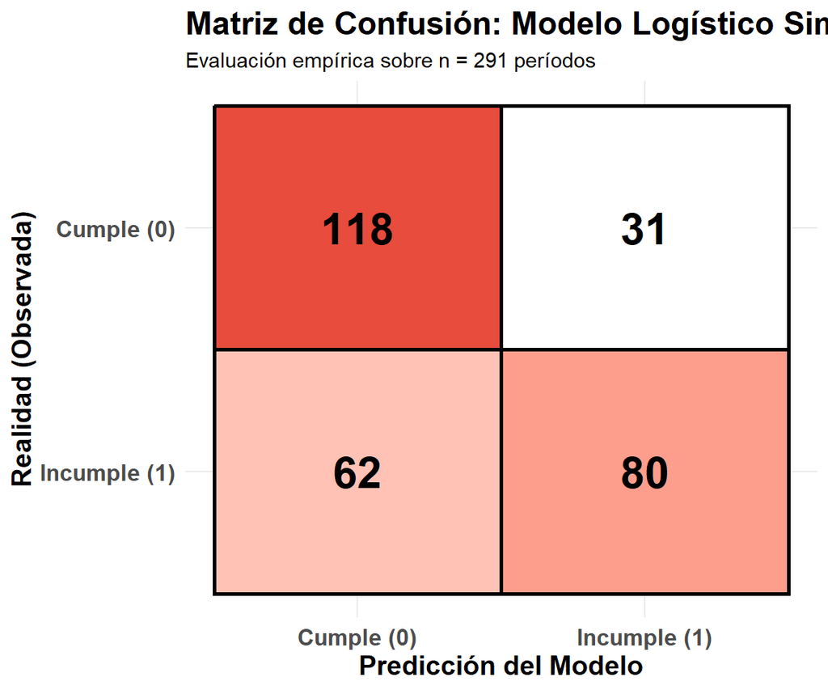

```r
prob_s   <- predict(modelo_sede_simple, type = "response")
pred_s   <- ifelse(prob_s > 0.5, 1, 0)
mc_s     <- table(Prediccion = pred_s, Real = dt_sede$Sede_Incumple)

VN_s <- mc_s["0", "0"]; FN_s <- mc_s["0", "1"]
FP_s <- mc_s["1", "0"]; VP_s <- mc_s["1", "1"]

acc_s  <- (VP_s + VN_s) / sum(mc_s)
sens_s <- VP_s / (VP_s + FN_s)
esp_s  <- VN_s / (VN_s + FP_s)

# ── Gráfico: Matriz de Confusión estilo heatmap ──────────────────────────────
datos_mc_s <- data.frame(
  Predicho   = factor(c("Cumple (0)", "Incumple (1)", "Cumple (0)", "Incumple (1)"),
                      levels = c("Cumple (0)", "Incumple (1)")),
  Real       = factor(c("Cumple (0)", "Cumple (0)", "Incumple (1)", "Incumple (1)"),
                      levels = c("Incumple (1)", "Cumple (0)")),
  Frecuencia = c(VN_s, FP_s, FN_s, VP_s)
)

ggplot(datos_mc_s, aes(x = Predicho, y = Real, fill = Frecuencia)) +
  geom_tile(color = "black", linewidth = 1) +
  geom_text(aes(label = Frecuencia), size = 8, fontface = "bold") +
  scale_fill_gradient(low = "white", high = "#E74C3C") +
  labs(title    = "Matriz de Confusión: Modelo Logístico Simple — Sede",
       subtitle = paste0("Evaluación empírica sobre n = ", sum(mc_s), " períodos"),
       x        = "Predicción del Modelo",
       y        = "Realidad (Observada)") +
  theme_minimal() +
  theme(axis.text  = element_text(size = 12, face = "bold"),
        title      = element_text(size = 14, face = "bold"),
        legend.position = "none")
```

**Ver código**

```r
metricas_s <- data.frame(
  Métrica = c("Exactitud global (Accuracy)",
              "Sensibilidad (Recall — detectar incumplimientos)",
              "Especificidad (descartar cumplimientos)"),
  Valor   = paste0(round(c(acc_s, sens_s, esp_s) * 100, 2), "%"),
  Interpretacion = c(
    "Proporción total de clasificaciones correctas",
    "De todos los meses que SÍ hubo incumplimiento, ¿cuántos detectó el modelo?",
    "De todos los meses donde se cumplió la norma, ¿cuántos identificó correctamente?"
  )
)

apa_table(metricas_s,
         col.names = c("Métrica", "Valor", "Interpretación"),
         caption   = "Métricas de Desempeño — Modelo Simple Sede",
         align     = c("l", "r", "l"))
```

Métricas de Desempeño — Modelo Simple Sede

| Métrica | Valor | Interpretación |
| --- | --- | --- |
| Exactitud global (Accuracy) | 68.04% | Proporción total de clasificaciones correctas |
| Sensibilidad (Recall — detectar incumplimientos) | 56.34% | De todos los meses que SÍ hubo incumplimiento, ¿cuántos detectó el modelo? |
| Especificidad (descartar cumplimientos) | 79.19% | De todos los meses donde se cumplió la norma, ¿cuántos identificó correctamente? |

# 5 Modelo Logístico Múltiple — Nivel Sede

Se incorpora `Vacaciones` como covariable dicotómica para evaluar si los meses de receso académico (Enero, Junio, Julio y Diciembre) influyen en la probabilidad de incumplimiento normativo, controlando por el nivel de consumo activo. Al ser una sola dummy, el modelo es parsimonioso y responde directamente: **¿estar en vacaciones aumenta el riesgo de incumplimiento?**

$$\ln\left(\frac{P}{1-P}\right) = \beta_0 + \beta_1 \cdot Activa\_Total + \beta_2 \cdot Vacaciones$$

## 5.1 Estimación del Modelo

**Ver código**

```r
# Vacaciones ya existe en Resumen_Sede.csv (1 = Ene, Jun, Jul, Dic; 0 = resto)

modelo_sede_mult <- glm(Sede_Incumple ~ Activa_Total + Vacaciones,
                         data   = dt_sede,
                         family = binomial(link = "logit"))

resumen_m <- summary(modelo_sede_mult)
coef_m    <- coef(modelo_sede_mult)

# ── Tabla de coeficientes ──────────────────────────────────────────────────────
coef_tabla_m <- data.frame(
  Parámetro   = c("β₀ (Intercepto)", "β₁ (Activa_Total)", "β₂ (Vacaciones)"),
  Estimador   = round(resumen_m$coefficients[, 1], 6),
  Error_Std   = round(resumen_m$coefficients[, 2], 6),
  z           = round(resumen_m$coefficients[, 3], 4),
  p_valor     = format(resumen_m$coefficients[, 4], scientific = TRUE)
)

apa_table(coef_tabla_m,
         col.names = c("Parámetro", "Estimador", "Error Estándar", "z", "p-valor"),
         caption   = "Coeficientes del Modelo Logístico Múltiple — Nivel Sede (Activa + Vacaciones)",
         align     = c("l", "r", "r", "r", "r"),
         nota      = "Vacaciones = 1 para meses de receso académico (Ene, Jun, Jul, Dic); 0 = meses de clases.")
```

Coeficientes del Modelo Logístico Múltiple — Nivel Sede (Activa + Vacaciones)

| Parámetro | Estimador | Error Estándar | z | p-valor |
| --- | --- | --- | --- | --- |
| β₀ (Intercepto) | -4.034540 | 0.571872 | -7.0550 | 1.726404e-12 |
| β₁ (Activa_Total) | 0.000027 | 0.000004 | 7.2834 | 3.255331e-13 |
| β₂ (Vacaciones) | 1.385895 | 0.337215 | 4.1098 | 3.959527e-05 |

Nota. Vacaciones = 1 para meses de receso académico (Ene, Jun, Jul, Dic); 0 = meses de clases.

**Ver código**

```r
# ── Indicadores de ajuste ─────────────────────────────────────────────────────
ajuste_m <- data.frame(
  Indicador = c("Devianza nula", "Devianza residual", "AIC", "N observaciones"),
  Valor     = c(round(resumen_m$null.deviance, 2),
                round(resumen_m$deviance, 2),
                round(resumen_m$aic, 2),
                nrow(dt_sede))
)

apa_table(ajuste_m,
         col.names = c("Indicador", "Valor"),
         caption   = "Indicadores de Ajuste — Modelo Logístico Múltiple (Sede)",
         align     = c("l", "r"))
```

Indicadores de Ajuste — Modelo Logístico Múltiple (Sede)

| Indicador | Valor |
| --- | --- |
| Devianza nula | 403.24 |
| Devianza residual | 327.43 |
| AIC | 333.43 |
| N observaciones | 291.00 |

Los coeficientes del modelo revelan dos efectos simultáneos sobre el riesgo de incumplimiento normativo de la sede. El signo positivo de $\hat{\beta}_1$ confirma que a mayor consumo de energía activa, mayor es la probabilidad de que alguna cuenta supere el umbral de 0.48 — consistente con lo observado en el gráfico exploratorio de la Sección 3, donde los períodos de mayor consumo coincidían visualmente con más cuentas en incumplimiento. El signo positivo de $\hat{\beta}_2$ indica que los meses de vacaciones representan un riesgo adicional de incumplimiento incluso controlando por el nivel de consumo activo: en receso académico la demanda cae pero las cargas inductivas instaladas — transformadores, aires acondicionados, motores — permanecen energizadas, elevando la relación Reactiva/Activa por encima del límite normativo de 0.48 establecido por la CREG 015 de 2018.

## 5.2 Ecuación e Interpretación

**ImportantEcuación del Modelo Logístico Múltiple**

**Escala Log-Odds:**

$$\ln\left(\frac{P}{1-P}\right) = -4.0345 + 0.00002714 \cdot Activa\_Total + 1.3859 \cdot Vacaciones$$

**Escala de Probabilidad (Sigmoide):**

$$P(Incumple) = \frac{1}{1 + e^{-(-4.0345 + 0.00002714 \cdot Activa\_Total + 1.3859 \cdot Vacaciones)}}$$

**Interpretación de los coeficientes:**

- $\hat{\beta}_1$ = 0.00002714 → Por cada kWh adicional de energía activa total, el log-odds de incumplimiento cambia en 0.00002714 unidades, manteniendo constante el estado de vacaciones.
- $\hat{\beta}_2$ = 1.3859 (p = < 0.001) → Los meses de vacaciones (Ene, Jun, Jul, Dic) **aumentan** el log-odds de incumplimiento en 1.3859 unidades respecto a los meses de clases. En términos de **Odds Ratio**: $OR = e^{1.3859} = 3.9984$ — el riesgo de incumplimiento es mayor en vacaciones.

**Ver código**

```r
or_mult <- exp(cbind(OR = coef(modelo_sede_mult),
                      confint(modelo_sede_mult)))

or_mult_df <- as.data.frame(round(or_mult, 4))
or_mult_df$Variable <- c("Intercepto", "Activa_Total", "Vacaciones")
or_mult_df$p_valor  <- round(resumen_m$coefficients[, 4], 6)
or_mult_df$Interpretacion <- c(
  "Punto de anclaje matemático",
  ifelse(exp(coef_m[2]) > 1,
    "Mayor consumo activo → mayor riesgo de incumplir (Ceteris Paribus)",
    "Mayor consumo activo → menor riesgo de incumplir (Ceteris Paribus)"),
  ifelse(exp(coef_m[3]) > 1,
    "Vacaciones AUMENTAN el riesgo de incumplimiento vs. meses de clases",
    "Vacaciones REDUCEN el riesgo de incumplimiento vs. meses de clases")
)

apa_table(or_mult_df[, c("Variable", "OR", "2.5 %", "97.5 %",
                         "p_valor", "Interpretacion")],
         col.names = c("Variable", "OR", "IC 2.5%", "IC 97.5%",
                       "p-valor", "Interpretación"),
         caption   = "Odds Ratios — Modelo Logístico Múltiple (Sede: Activa + Vacaciones)",
         align     = c("l", "r", "r", "r", "r", "l"),
         nota      = "Vacaciones = 1 (Ene, Jun, Jul, Dic); 0 = meses de clases. OR > 1 = mayor riesgo en vacaciones.")
```

Odds Ratios — Modelo Logístico Múltiple (Sede: Activa + Vacaciones)

| Variable | OR | IC 2.5% | IC 97.5% | p-valor | Interpretación |
| --- | --- | --- | --- | --- | --- |
| Intercepto | 0.0177 | 0.0055 | 0.0517 | 0e+00 | Punto de anclaje matemático |
| Activa_Total | 1.0000 | 1.0000 | 1.0000 | 0e+00 | Mayor consumo activo → mayor riesgo de incumplir (Ceteris Paribus) |
| Vacaciones | 3.9984 | 2.0928 | 7.8722 | 4e-05 | Vacaciones AUMENTAN el riesgo de incumplimiento vs. meses de clases |

Nota. Vacaciones = 1 (Ene, Jun, Jul, Dic); 0 = meses de clases. OR > 1 = mayor riesgo en vacaciones.

## 5.3 Comparación de Modelos por AIC — Nivel Sede

**Ver código**

```r
modelos_sede <- list(
  "M1: ~ Activa_Total"              = glm(Sede_Incumple ~ Activa_Total,
                                           data = dt_sede, family = "binomial"),
  "M2: ~ Vacaciones"                = glm(Sede_Incumple ~ Vacaciones,
                                           data = dt_sede, family = "binomial"),
  "M3: ~ Activa_Total + Vacaciones" = modelo_sede_mult
)

tabla_aic_sede <- data.frame(
  Modelo     = names(modelos_sede),
  Parámetros = sapply(modelos_sede, function(m) length(coef(m))),
  AIC        = round(sapply(modelos_sede, AIC), 2),
  Devianza   = round(sapply(modelos_sede, function(m) m$deviance), 2)
)
tabla_aic_sede <- tabla_aic_sede[order(tabla_aic_sede$AIC), ]
tabla_aic_sede$Ranking <- 1:nrow(tabla_aic_sede)

apa_table(tabla_aic_sede,
         col.names = c("Modelo", "Parámetros", "AIC", "Devianza", "Ranking"),
         caption   = "Comparación de Modelos por AIC — Nivel Sede (menor AIC = mejor)",
         align     = c("l", "c", "r", "r", "c"))
```

Comparación de Modelos por AIC — Nivel Sede (menor AIC = mejor)

| Modelo | Parámetros | AIC | Devianza | Ranking |
| --- | --- | --- | --- | --- |
| M3: ~ Activa_Total + Vacaciones | 3 | 333.43 | 327.43 | 1 |
| M1: ~ Activa_Total | 2 | 349.72 | 345.72 | 2 |
| M2: ~ Vacaciones | 2 | 407.13 | 403.13 | 3 |

La comparación por AIC muestra que el modelo con `Vacaciones` supera al modelo simple en capacidad predictiva. Este resultado valida estadísticamente que el calendario académico no es un factor irrelevante: los meses de receso aportan información predictiva real que el consumo activo por sí solo no captura. El modelo seleccionado — `Activa_Total + Vacaciones` — es el referente de nivel sede contra el que se compararán los modelos de la Sección 6.

## 5.4 Matriz de Confusión — Modelo Múltiple Sede

**Ver código**

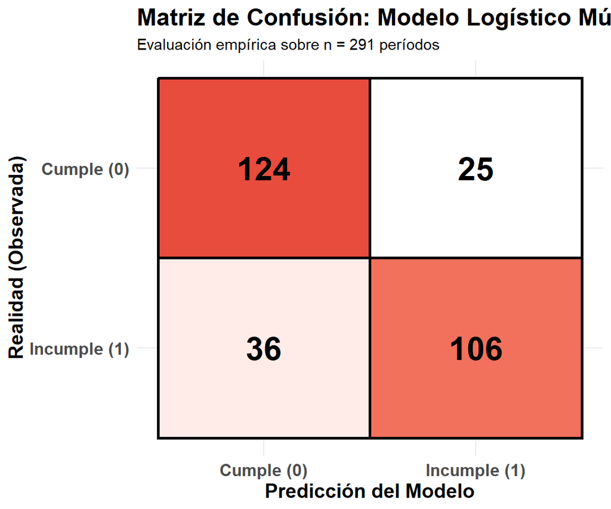

```r
prob_m  <- predict(modelo_sede_mult, type = "response")
pred_m  <- ifelse(prob_m > 0.5, 1, 0)
mc_m    <- table(Prediccion = pred_m, Real = dt_sede$Sede_Incumple)

VN_m <- mc_m["0","0"]; FN_m <- mc_m["0","1"]
FP_m <- mc_m["1","0"]; VP_m <- mc_m["1","1"]

acc_m  <- (VP_m + VN_m) / sum(mc_m)
sens_m <- VP_m / (VP_m + FN_m)
esp_m  <- VN_m / (VN_m + FP_m)

# ── Gráfico: Matriz de Confusión estilo heatmap ──────────────────────────────
datos_mc_m <- data.frame(
  Predicho   = factor(c("Cumple (0)", "Incumple (1)", "Cumple (0)", "Incumple (1)"),
                      levels = c("Cumple (0)", "Incumple (1)")),
  Real       = factor(c("Cumple (0)", "Cumple (0)", "Incumple (1)", "Incumple (1)"),
                      levels = c("Incumple (1)", "Cumple (0)")),
  Frecuencia = c(VN_m, FP_m, FN_m, VP_m)
)

ggplot(datos_mc_m, aes(x = Predicho, y = Real, fill = Frecuencia)) +
  geom_tile(color = "black", linewidth = 1) +
  geom_text(aes(label = Frecuencia), size = 8, fontface = "bold") +
  scale_fill_gradient(low = "white", high = "#E74C3C") +
  labs(title    = "Matriz de Confusión: Modelo Logístico Múltiple — Sede",
       subtitle = paste0("Evaluación empírica sobre n = ", sum(mc_m), " períodos"),
       x        = "Predicción del Modelo",
       y        = "Realidad (Observada)") +
  theme_minimal() +
  theme(axis.text  = element_text(size = 12, face = "bold"),
        title      = element_text(size = 14, face = "bold"),
        legend.position = "none")
```

**Ver código**

```r
comp_metricas <- data.frame(
  Métrica        = c("Accuracy", "Sensibilidad", "Especificidad", "AIC"),
  Modelo_Simple  = c(paste0(round(acc_s  * 100, 2), "%"),
                     paste0(round(sens_s * 100, 2), "%"),
                     paste0(round(esp_s  * 100, 2), "%"),
                     round(AIC(modelo_sede_simple), 2)),
  Modelo_Multiple = c(paste0(round(acc_m  * 100, 2), "%"),
                      paste0(round(sens_m * 100, 2), "%"),
                      paste0(round(esp_m  * 100, 2), "%"),
                      round(AIC(modelo_sede_mult), 2))
)

apa_table(comp_metricas,
         col.names = c("Métrica", "Modelo Simple", "Modelo Múltiple"),
         caption   = "Comparación de Desempeño — Modelos Nivel Sede",
         align     = c("l", "r", "r"))
```

Comparación de Desempeño — Modelos Nivel Sede

| Métrica | Modelo Simple | Modelo Múltiple |
| --- | --- | --- |
| Accuracy | 68.04% | 79.04% |
| Sensibilidad | 56.34% | 74.65% |
| Especificidad | 79.19% | 83.22% |
| AIC | 349.72 | 333.43 |

La incorporación de `Vacaciones` no solo mejora el AIC sino que se traduce en una mejora del poder diagnóstico del modelo. La sensibilidad — capacidad de detectar correctamente los meses con incumplimiento — es la métrica más relevante desde el punto de vista operativo: un modelo que falla en detectar el incumplimiento implica que la universidad no anticipa el recargo y llega a la factura sin haber tomado medidas correctivas. La comparación de ambos modelos permite cuantificar exactamente cuánto mejora esa capacidad de alerta al incorporar el factor estacional.

# 6 Modelo Logístico — Impacto por Cuenta Individual sobre el Incumplimiento de Sede

En las secciones anteriores se modeló el incumplimiento de sede usando el consumo activo agregado (total de las 5 cuentas). Ahora se evalúa una pregunta diferente: ¿el consumo de cuál cuenta individual es más informativo para predecir si la sede incumplirá la norma?

Para responderlo se construyen modelos logísticos simples — uno por cada cuenta (`Activa` individual → `Sede_Incumple`) — y se comparan por AIC. Con los mejores predictores se arma un modelo múltiple final.

## 6.1 Preparación: Consumo Individual en Formato Ancho

**Ver código**

```r
library(tidyr)
activa_wide <- dt_cuenta %>%
  select(Tiempo, Nombre_Cuenta, Activa) %>%
  mutate(Activa_k = Activa / 1000) %>%
  select(Tiempo, Nombre_Cuenta, Activa_k) %>%
  pivot_wider(
    names_from   = Nombre_Cuenta,
    values_from  = Activa_k,
    names_prefix = "Activa_k_"
  )

colnames(activa_wide) <- make.names(colnames(activa_wide))

dt_sede_ind <- dt_sede %>%
  left_join(activa_wide, by = "Tiempo")

nombres_activa <- grep("^Activa_k_", colnames(dt_sede_ind), value = TRUE)

apa_table(
  data.frame(
    Variable  = nombres_activa,
    N_validos = sapply(nombres_activa,
                       function(v) sum(!is.na(dt_sede_ind[[v]]))),
    Media     = round(sapply(nombres_activa,
                             function(v) mean(dt_sede_ind[[v]], na.rm = TRUE)), 1),
    DE        = round(sapply(nombres_activa,
                             function(v) sd(dt_sede_ind[[v]], na.rm = TRUE)), 1)
  ),
  col.names = c("Variable", "N válidos", "Media (MWh)", "DE"),
  caption   = "Descriptivos de Energía Activa Individual — Formato Ancho",
  align     = c("l", "c", "r", "r")
)
```

Descriptivos de Energía Activa Individual — Formato Ancho

| Variable | N válidos | Media (MWh) | DE |
| --- | --- | --- | --- |
| Activa_k_Central.1 | 286 | 25.5 | 9.4 |
| Activa_k_Central.4 | 277 | 26.3 | 10.9 |
| Activa_k_Central.2 | 286 | 78.9 | 38.5 |
| Activa_k_Central.5 | 239 | 1.3 | 1.2 |
| Activa_k_Central.3 | 24 | 15.7 | 11.2 |

## 6.2 Modelos Simples: Cada Cuenta → Sede_Incumple

**Ver código**

```r
# ── Lista de predictores candidatos ───────────────────────────────────────────
predictores <- nombres_activa

resultados_simples <- lapply(predictores, function(pred) {
  formula_i <- as.formula(paste("Sede_Incumple ~", pred))
  datos_i   <- dt_sede_ind[!is.na(dt_sede_ind[[pred]]), ]
  modelo_i  <- tryCatch(
    glm(formula_i, data = datos_i, family = binomial(link = "logit")),
    error = function(e) NULL
  )
  if (is.null(modelo_i)) return(NULL)

  coef_i  <- coef(modelo_i)
  pval_i  <- summary(modelo_i)$coefficients[2, 4]
  or_i    <- exp(coef_i[2])
  aic_i   <- AIC(modelo_i)
  n_i     <- nrow(datos_i)

  data.frame(
    Predictor = pred,
    N         = n_i,
    b1        = round(coef_i[2], 7),
    OR        = round(or_i, 4),
    p_valor   = round(pval_i, 6),
    AIC       = round(aic_i, 2),
    Signif    = ifelse(pval_i < 0.05, "✓ Sí", "✗ No"),
    Efecto    = ifelse(or_i > 1,
                       "Mayor consumo → mayor riesgo de incumplimiento sede",
                       "Mayor consumo → menor riesgo de incumplimiento sede")
  )
})

tabla_simples <- do.call(rbind, resultados_simples)
tabla_simples <- tabla_simples[order(tabla_simples$AIC), ]
tabla_simples$Ranking <- 1:nrow(tabla_simples)

apa_table(tabla_simples,
         col.names = c("Predictor", "N", "β₁", "OR", "p-valor",
                       "AIC", "Significativo", "Dirección del efecto", "Ranking"),
         caption   = "Comparación de Modelos Simples — Predictor Individual → Incumplimiento Sede",
         align     = c("l", "c", "r", "r", "r", "r", "c", "l", "c"),
         nota      = paste0(
           "Cada modelo es logístico simple: Sede_Incumple ~ Predictor. ",
           "Central 3 tiene EPV = 0 (solo 24 períodos válidos); ",
           "su resultado se reporta con fines descriptivos únicamente. ",
           "Ordenado por AIC ascendente."))
```

Comparación de Modelos Simples — Predictor Individual → Incumplimiento Sede

| Predictor | N | β₁ | OR | p-valor | AIC | Significativo | Dirección del efecto | Ranking |
| --- | --- | --- | --- | --- | --- | --- | --- | --- |
| Activa_k_Central.3 | 24 | -0.0104329 | 0.9896 | 0.876231 | 17.74 | ✗ No | Mayor consumo → menor riesgo de incumplimiento sede | 1 |
| Activa_k_Central.2 | 286 | 0.0430661 | 1.0440 | 0.000000 | 284.77 | ✓ Sí | Mayor consumo → mayor riesgo de incumplimiento sede | 2 |
| Activa_k_Central.5 | 239 | 0.7063364 | 2.0266 | 0.000000 | 301.51 | ✓ Sí | Mayor consumo → mayor riesgo de incumplimiento sede | 3 |
| Activa_k_Central.4 | 277 | -0.1010292 | 0.9039 | 0.000000 | 326.52 | ✓ Sí | Mayor consumo → menor riesgo de incumplimiento sede | 4 |
| Activa_k_Central.1 | 286 | 0.0183367 | 1.0185 | 0.150605 | 398.34 | ✗ No | Mayor consumo → mayor riesgo de incumplimiento sede | 5 |

Nota. Cada modelo es logístico simple: Sede_Incumple ~ Predictor. Central 3 tiene EPV = 0 (solo 24 períodos válidos); su resultado se reporta con fines descriptivos únicamente. Ordenado por AIC ascendente.

Los predictores con menor AIC identifican las cuentas cuyo consumo activo individual aporta mayor información predictiva sobre el incumplimiento normativo de la sede. Estos predictores son seleccionados para construir el modelo múltiple final.

**Nota metodológica — Central 3 en el modelo múltiple:** Aunque Central 3 se incluye en la tabla comparativa anterior, no se incorpora al modelo múltiple. Al combinarse con otras predictoras se detectó separación perfecta: clasificación casi determinista del incumplimiento que impide la convergencia del algoritmo de Máxima Verosimilitud (MLE), con OR = 0 o Inf, IC = [0, Inf] y p-valores de ~0.99 simultáneamente. Adicionalmente su EPV = 0 la hace inestable como predictora.

## 6.3 Modelo Múltiple Final — Central 2, Central 5 y Vacaciones

**Ver código**

```r
# ── Filtrar períodos válidos para los dos predictores seleccionados ────────────
dt_modelo_final <- dt_sede_ind %>%
  filter(!is.na(Activa_k_Central.2),
         !is.na(Activa_k_Central.5))
cat("Períodos válidos para el modelo final:", nrow(dt_modelo_final), "\n")
```

```
Períodos válidos para el modelo final: 237
```

**Ver código**

```r
# Modelo A: Central 2 + Central 5
modelo_cuentas_a <- glm(Sede_Incumple ~ Activa_k_Central.2 +
                                        Activa_k_Central.5,
                        data   = dt_modelo_final,
                        family = binomial(link = "logit"))

# Modelo B: Central 2 + Central 5 + Vacaciones
modelo_cuentas_b <- glm(Sede_Incumple ~ Activa_k_Central.2 +
                                        Activa_k_Central.5 +
                                        Vacaciones,
                        data   = dt_modelo_final,
                        family = binomial(link = "logit"))

resumen_s7m <- summary(modelo_cuentas_b)

# ── Tabla de coeficientes ──────────────────────────────────────────────────────
coef_tabla_f <- data.frame(
  Parámetro = c("β₀ (Intercepto)", "Activa_k_Central.2",
                "Activa_k_Central.5", "Vacaciones"),
  Estimador = round(resumen_s7m$coefficients[, 1], 6),
  Error_Std = round(resumen_s7m$coefficients[, 2], 6),
  z         = round(resumen_s7m$coefficients[, 3], 4),
  p_valor   = format(resumen_s7m$coefficients[, 4], scientific = TRUE)
)

apa_table(coef_tabla_f,
         col.names = c("Parámetro", "Estimador", "Error Estándar", "z", "p-valor"),
         caption   = "Coeficientes — Modelo Múltiple: Central 2 + Central 5 + Vacaciones",
         align     = c("l", "r", "r", "r", "r"),
         nota      = paste0(
           "Categoría de referencia Vacaciones: meses de clases (0). ",
           "Vacaciones = 1 para Enero, Junio, Julio y Diciembre."))
```

Coeficientes — Modelo Múltiple: Central 2 + Central 5 + Vacaciones

| Parámetro | Estimador | Error Estándar | z | p-valor |
| --- | --- | --- | --- | --- |
| β₀ (Intercepto) | -5.637072 | 0.735411 | -7.6652 | 1.785565e-14 |
| Activa_k_Central.2 | 0.069531 | 0.009970 | 6.9739 | 3.081965e-12 |
| Activa_k_Central.5 | -0.421437 | 0.240329 | -1.7536 | 7.950137e-02 |
| Vacaciones | 1.859629 | 0.420108 | 4.4265 | 9.575326e-06 |

Nota. Categoría de referencia Vacaciones: meses de clases (0). Vacaciones = 1 para Enero, Junio, Julio y Diciembre.

**Ver código**

```r
# ── Indicadores de ajuste completos ──────────────────────────────────────────
ajuste_s7 <- data.frame(
  Indicador = c("Devianza nula", "GL nula",
                "Devianza residual", "GL residual",
                "Reducción de devianza",
                "AIC", "N observaciones",
                "Iteraciones Fisher Scoring"),
  Valor = c(round(resumen_s7m$null.deviance,            2),
            resumen_s7m$df.null,
            round(resumen_s7m$deviance,                 2),
            resumen_s7m$df.residual,
            round(resumen_s7m$null.deviance -
                  resumen_s7m$deviance,                 2),
            round(resumen_s7m$aic,                      2),
            nrow(dt_modelo_final),
            resumen_s7m$iter)
)

apa_table(ajuste_s7,
         col.names = c("Indicador", "Valor"),
         caption   = "Indicadores de Ajuste — Modelo Múltiple Final",
         align     = c("l", "r"))
```

Indicadores de Ajuste — Modelo Múltiple Final

| Indicador | Valor |
| --- | --- |
| Devianza nula | 327.03 |
| GL nula | 236.00 |
| Devianza residual | 199.45 |
| GL residual | 233.00 |
| Reducción de devianza | 127.58 |
| AIC | 207.45 |
| N observaciones | 237.00 |
| Iteraciones Fisher Scoring | 5.00 |

### 6.3.1 Odds Ratios — Modelo Múltiple Final

**Ver código**

```r
or_final <- exp(cbind(OR = coef(modelo_cuentas_b),
                       confint(modelo_cuentas_b)))
or_final_df <- as.data.frame(round(or_final, 4))
or_final_df$p_valor <- round(resumen_s7m$coefficients[, 4], 6)
or_final_df$Signif  <- ifelse(or_final_df$p_valor < 0.05, "✓ Sí", "✗ No")
rownames(or_final_df) <- c("β₀ (Intercepto)", "Activa_k_Central.2",
                            "Activa_k_Central.5", "Vacaciones")

apa_table(or_final_df[, c("OR", "2.5 %", "97.5 %", "p_valor", "Signif")],
         col.names = c("OR", "IC 2.5%", "IC 97.5%", "p-valor", "Significativo"),
         caption   = "Odds Ratios — Modelo Múltiple Final (Central 2 + Central 5 + Vacaciones)",
         align     = c("r", "r", "r", "r", "c"),
         nota      = "OR > 1 = mayor consumo/vacaciones aumenta riesgo de incumplimiento sede.")
```

Odds Ratios — Modelo Múltiple Final (Central 2 + Central 5 + Vacaciones)

| OR | IC 2.5% | IC 97.5% | p-valor | Significativo |
| --- | --- | --- | --- | --- |
| 0.0036 | 0.0008 | 0.0137 | 0.000000 | ✓ Sí |
| 1.0720 | 1.0529 | 1.0951 | 0.000000 | ✓ Sí |
| 0.6561 | 0.3966 | 1.0229 | 0.079501 | ✗ No |
| 6.4214 | 2.9067 | 15.1961 | 0.000010 | ✓ Sí |

Nota. OR > 1 = mayor consumo/vacaciones aumenta riesgo de incumplimiento sede.

Los Odds Ratios del modelo múltiple final revelan un resultado metodológicamente relevante: **Central 5 no resulta estadísticamente significativa** (p > 0.05) cuando se controla simultáneamente por Central 2 y Vacaciones. Este fenómeno — denominado supresión en el contexto multivariante — indica que el efecto predictivo de Central 5 observado en el modelo simple de la Sección 6.2 estaba parcialmente mediado por su correlación con Central 2. En la práctica operativa esto significa que la atención debe concentrarse en **Central 2** como el punto crítico primario de gestión, sin descartar el monitoreo de Central 5 como indicador secundario. **Vacaciones** mantiene su significancia y dirección en el modelo múltiple, confirmando la robustez del efecto estacional identificado en la Sección 5.

### 6.3.2 Matriz de Confusión y Métricas — Modelo Final

**Ver código**

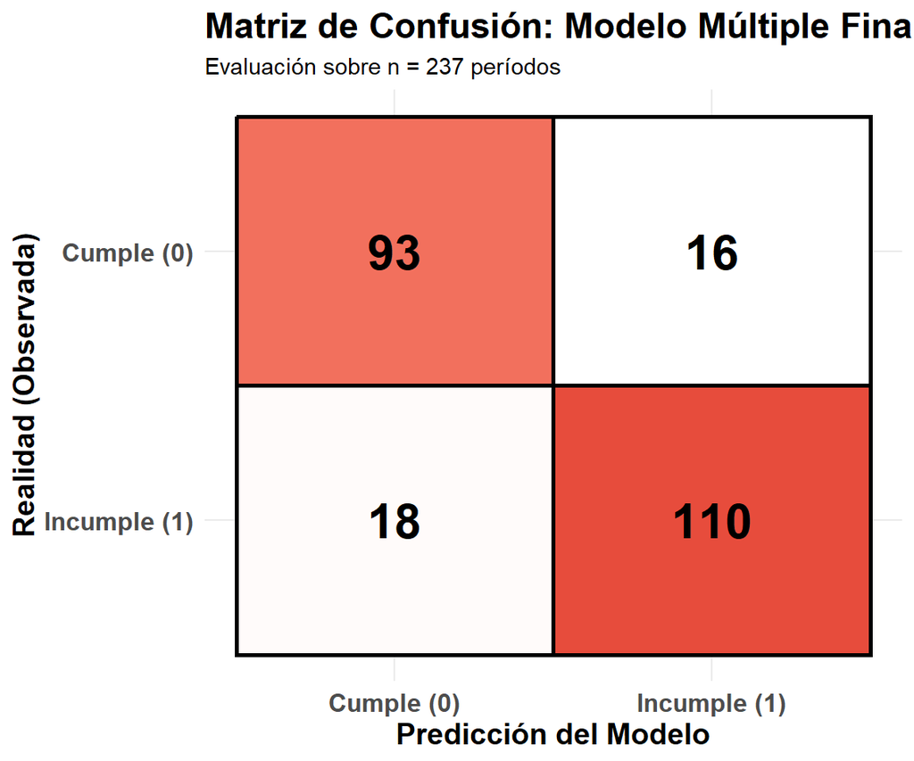

```r
prob_f  <- predict(modelo_cuentas_b, type = "response")
pred_f  <- ifelse(prob_f > 0.5, 1, 0)
real_f  <- dt_modelo_final$Sede_Incumple
mc_f    <- table(Prediccion = pred_f, Real = real_f)

VN_f <- mc_f["0","0"]; FN_f <- mc_f["0","1"]
FP_f <- mc_f["1","0"]; VP_f <- mc_f["1","1"]

acc_f  <- (VP_f + VN_f) / sum(mc_f)
sens_f <- VP_f / (VP_f + FN_f)
esp_f  <- VN_f / (VN_f + FP_f)

datos_mc_f <- data.frame(
  Predicho   = factor(c("Cumple (0)", "Incumple (1)",
                         "Cumple (0)", "Incumple (1)"),
                      levels = c("Cumple (0)", "Incumple (1)")),
  Real       = factor(c("Cumple (0)", "Cumple (0)",
                         "Incumple (1)", "Incumple (1)"),
                      levels = c("Incumple (1)", "Cumple (0)")),
  Frecuencia = c(VN_f, FP_f, FN_f, VP_f)
)

ggplot(datos_mc_f, aes(x = Predicho, y = Real, fill = Frecuencia)) +
  geom_tile(color = "black", linewidth = 1) +
  geom_text(aes(label = Frecuencia), size = 8, fontface = "bold") +
  scale_fill_gradient(low = "white", high = "#E74C3C") +
  labs(title    = "Matriz de Confusión: Modelo Múltiple Final",
       subtitle = paste0("Evaluación sobre n = ", sum(mc_f), " períodos"),
       x = "Predicción del Modelo",
       y = "Realidad (Observada)") +
  theme_minimal() +
  theme(axis.text = element_text(size = 12, face = "bold"),
        title     = element_text(size = 14, face = "bold"),
        legend.position = "none")
```

**Ver código**

```r
metricas_f <- data.frame(
  Métrica = c("Exactitud global (Accuracy)",
              "Sensibilidad (detectar incumplimientos)",
              "Especificidad (descartar cumplimientos)"),
  Valor   = paste0(round(c(acc_f, sens_f, esp_f) * 100, 2), "%"),
  Interpretacion = c(
    "Proporción total de clasificaciones correctas",
    "De todos los meses con incumplimiento, ¿cuántos detectó el modelo?",
    "De todos los meses donde se cumplió la norma, ¿cuántos identificó correctamente?"
  )
)

apa_table(metricas_f,
         col.names = c("Métrica", "Valor", "Interpretación"),
         caption   = "Métricas de Desempeño — Modelo Múltiple Final",
         align     = c("l", "r", "l"))
```

Métricas de Desempeño — Modelo Múltiple Final

| Métrica | Valor | Interpretación |
| --- | --- | --- |
| Exactitud global (Accuracy) | 85.65% | Proporción total de clasificaciones correctas |
| Sensibilidad (detectar incumplimientos) | 85.94% | De todos los meses con incumplimiento, ¿cuántos detectó el modelo? |
| Especificidad (descartar cumplimientos) | 85.32% | De todos los meses donde se cumplió la norma, ¿cuántos identificó correctamente? |

## 6.4 Central 2: Modelo Logístico Propio

**Ver código**

```r
# ── Filtrar datos de Central 2 ────────────────────────────────────────────────
# Cumple_bin y Vacaciones ya existen en Consumo_Central.csv
dt_c2 <- dt_cuenta %>%
  filter(Nombre_Cuenta == "Central 2") %>%
  mutate(Activa_k = Activa / 1000)

# ── Tabla resumen ─────────────────────────────────────────────────────────────
n_c2         <- nrow(dt_c2)
incumple_c2  <- sum(dt_c2$Cumple_bin == 0)
pct_inc_c2   <- round(incumple_c2 / n_c2 * 100, 1)
epv_max_c2   <- floor(incumple_c2 / 10)

resumen_c2 <- data.frame(
  Concepto = c("N períodos totales",
               "Incumplimientos (Cumple = No)",
               "Porcentaje de incumplimiento",
               "EPV máximo (floor(incumplimientos / 10))"),
  Valor    = c(as.character(n_c2),
               as.character(incumple_c2),
               paste0(pct_inc_c2, "%"),
               as.character(epv_max_c2))
)

apa_table(resumen_c2,
         col.names = c("Concepto", "Valor"),
         caption   = "Distribución del Cumplimiento — Central 2",
         align     = c("l", "r"))
```

Distribución del Cumplimiento — Central 2

| Concepto | Valor |
| --- | --- |
| N períodos totales | 286 |
| Incumplimientos (Cumple = No) | 139 |
| Porcentaje de incumplimiento | 48.6% |
| EPV máximo (floor(incumplimientos / 10)) | 13 |

**Ver código**

```r
# ── Modelo logístico simple ───────────────────────────────────────────────────
modelo_c2_s <- glm(Cumple_bin ~ Activa_k,
                   data   = dt_c2,
                   family = binomial(link = "logit"))

resumen_c2_s <- summary(modelo_c2_s)

# ── 1. Tabla de coeficientes ─────────────────────────────────────────────────
coef_c2_s <- data.frame(
  Parámetro = c("β₀ (Intercepto)", "β₁ (Activa_k)"),
  Estimador = round(resumen_c2_s$coefficients[, 1], 6),
  Error_Std = round(resumen_c2_s$coefficients[, 2], 6),
  z         = round(resumen_c2_s$coefficients[, 3], 4),
  p_valor   = format(resumen_c2_s$coefficients[, 4], scientific = TRUE)
)

apa_table(coef_c2_s,
         col.names = c("Parámetro", "Estimador", "Error Estándar", "z", "p-valor"),
         caption   = "Coeficientes — Modelo Simple Central 2",
         align     = c("l", "r", "r", "r", "r"))
```

Coeficientes — Modelo Simple Central 2

| Parámetro | Estimador | Error Estándar | z | p-valor |
| --- | --- | --- | --- | --- |
| β₀ (Intercepto) | 3.537885 | 0.415013 | 8.5248 | 1.531401e-17 |
| β₁ (Activa_k) | -0.045837 | 0.005424 | -8.4506 | 2.896920e-17 |

**Ver código**

```r
# ── 2. Tabla de Odds Ratios ──────────────────────────────────────────────────
or_c2_s <- exp(cbind(OR = coef(modelo_c2_s),
                      confint(modelo_c2_s)))
or_c2_s_df <- as.data.frame(round(or_c2_s, 6))
or_c2_s_df$Variable     <- c("Intercepto", "Activa_k")
or_c2_s_df$Significativo <- c("—",
  ifelse(resumen_c2_s$coefficients[2, 4] < 0.05, "✓ Sí (p < 0.05)", "✗ No"))

apa_table(or_c2_s_df[, c("Variable", "OR", "2.5 %", "97.5 %", "Significativo")],
         col.names = c("Variable", "OR", "IC 2.5%", "IC 97.5%", "Significativo"),
         caption   = "Odds Ratios — Modelo Simple Central 2",
         align     = c("l", "r", "r", "r", "c"))
```

Odds Ratios — Modelo Simple Central 2

| Variable | OR | IC 2.5% | IC 97.5% | Significativo |
| --- | --- | --- | --- | --- |
| Intercepto | 34.394099 | 15.846232 | 81.097503 | — |
| Activa_k | 0.955198 | 0.944387 | 0.964776 | ✓ Sí (p < 0.05) |

**Ver código**

```r
# ── 3. Indicadores de ajuste completos ────────────────────────────────────────
ajuste_c2_s <- data.frame(
  Indicador = c("Devianza nula", "GL nula",
                "Devianza residual", "GL residual",
                "Reducción de devianza",
                "AIC", "N observaciones",
                "Iteraciones Fisher Scoring"),
  Valor = c(round(resumen_c2_s$null.deviance, 2),
            resumen_c2_s$df.null,
            round(resumen_c2_s$deviance, 2),
            resumen_c2_s$df.residual,
            round(resumen_c2_s$null.deviance - resumen_c2_s$deviance, 2),
            round(resumen_c2_s$aic, 2),
            nrow(dt_c2),
            resumen_c2_s$iter)
)

apa_table(ajuste_c2_s,
         col.names = c("Indicador", "Valor"),
         caption   = "Indicadores de Ajuste — Modelo Simple Central 2",
         align     = c("l", "r"))
```

Indicadores de Ajuste — Modelo Simple Central 2

| Indicador | Valor |
| --- | --- |
| Devianza nula | 396.26 |
| GL nula | 285.00 |
| Devianza residual | 270.56 |
| GL residual | 284.00 |
| Reducción de devianza | 125.69 |
| AIC | 274.56 |
| N observaciones | 286.00 |
| Iteraciones Fisher Scoring | 5.00 |

**Ver código**

```r
# ── Modelo logístico múltiple ─────────────────────────────────────────────────
modelo_c2_m <- glm(Cumple_bin ~ Activa_k + Vacaciones,
                   data   = dt_c2,
                   family = binomial(link = "logit"))

resumen_c2_m <- summary(modelo_c2_m)

# ── 1. Tabla de coeficientes ─────────────────────────────────────────────────
coef_c2_m <- data.frame(
  Parámetro = c("β₀ (Intercepto)", "β₁ (Activa_k)", "β₂ (Vacaciones)"),
  Estimador = round(resumen_c2_m$coefficients[, 1], 6),
  Error_Std = round(resumen_c2_m$coefficients[, 2], 6),
  z         = round(resumen_c2_m$coefficients[, 3], 4),
  p_valor   = format(resumen_c2_m$coefficients[, 4], scientific = TRUE)
)

apa_table(coef_c2_m,
         col.names = c("Parámetro", "Estimador", "Error Estándar", "z", "p-valor"),
         caption   = "Coeficientes — Modelo Múltiple Central 2 (Activa + Vacaciones)",
         align     = c("l", "r", "r", "r", "r"),
         nota      = "Vacaciones = 1 para Enero, Junio, Julio y Diciembre; 0 meses de clases.")
```

Coeficientes — Modelo Múltiple Central 2 (Activa + Vacaciones)

| Parámetro | Estimador | Error Estándar | z | p-valor |
| --- | --- | --- | --- | --- |
| β₀ (Intercepto) | 4.977156 | 0.557516 | 8.9274 | 4.362396e-19 |
| β₁ (Activa_k) | -0.056173 | 0.006097 | -9.2136 | 3.153959e-20 |
| β₂ (Vacaciones) | -1.715912 | 0.367777 | -4.6656 | 3.076758e-06 |

Nota. Vacaciones = 1 para Enero, Junio, Julio y Diciembre; 0 meses de clases.

**Ver código**

```r
# ── 2. Tabla de Odds Ratios ──────────────────────────────────────────────────
or_c2_m <- exp(cbind(OR = coef(modelo_c2_m),
                      confint(modelo_c2_m)))
or_c2_m_df <- as.data.frame(round(or_c2_m, 4))
or_c2_m_df$Variable     <- c("Intercepto", "Activa_k", "Vacaciones")
or_c2_m_df$Significativo <- c("—",
  ifelse(resumen_c2_m$coefficients[2, 4] < 0.05, "✓ Sí (p < 0.05)", "✗ No"),
  ifelse(resumen_c2_m$coefficients[3, 4] < 0.05, "✓ Sí (p < 0.05)", "✗ No"))

apa_table(or_c2_m_df[, c("Variable", "OR", "2.5 %", "97.5 %", "Significativo")],
         col.names = c("Variable", "OR", "IC 2.5%", "IC 97.5%", "Significativo"),
         caption   = "Odds Ratios — Modelo Múltiple Central 2",
         align     = c("l", "r", "r", "r", "c"))
```

Odds Ratios — Modelo Múltiple Central 2

| Variable | OR | IC 2.5% | IC 97.5% | Significativo |
| --- | --- | --- | --- | --- |
| Intercepto | 145.0613 | 51.4205 | 460.8203 | — |
| Activa_k | 0.9454 | 0.9334 | 0.9561 | ✓ Sí (p < 0.05) |
| Vacaciones | 0.1798 | 0.0851 | 0.3618 | ✓ Sí (p < 0.05) |

**Ver código**

```r
# ── 3. Indicadores de ajuste completos ────────────────────────────────────────
ajuste_c2_m <- data.frame(
  Indicador = c("Devianza nula", "GL nula",
                "Devianza residual", "GL residual",
                "Reducción de devianza",
                "AIC", "N observaciones",
                "Iteraciones Fisher Scoring"),
  Valor = c(round(resumen_c2_m$null.deviance, 2),
            resumen_c2_m$df.null,
            round(resumen_c2_m$deviance, 2),
            resumen_c2_m$df.residual,
            round(resumen_c2_m$null.deviance - resumen_c2_m$deviance, 2),
            round(resumen_c2_m$aic, 2),
            nrow(dt_c2),
            resumen_c2_m$iter)
)

apa_table(ajuste_c2_m,
         col.names = c("Indicador", "Valor"),
         caption   = "Indicadores de Ajuste — Modelo Múltiple Central 2",
         align     = c("l", "r"))
```

Indicadores de Ajuste — Modelo Múltiple Central 2

| Indicador | Valor |
| --- | --- |
| Devianza nula | 396.26 |
| GL nula | 285.00 |
| Devianza residual | 245.75 |
| GL residual | 283.00 |
| Reducción de devianza | 150.50 |
| AIC | 251.75 |
| N observaciones | 286.00 |
| Iteraciones Fisher Scoring | 5.00 |

**Ver código**

[figure not shown]

```r
# ── Matriz de confusión del modelo múltiple ───────────────────────────────────
prob_c2   <- predict(modelo_c2_m, type = "response")
pred_c2   <- ifelse(prob_c2 > 0.5, 1, 0)
mc_c2     <- table(Prediccion = pred_c2, Real = dt_c2$Cumple_bin)

VN_c2 <- mc_c2["0", "0"]; FN_c2 <- mc_c2["0", "1"]
FP_c2 <- mc_c2["1", "0"]; VP_c2 <- mc_c2["1", "1"]

acc_c2  <- (VP_c2 + VN_c2) / sum(mc_c2)
sens_c2 <- VP_c2 / (VP_c2 + FN_c2)
esp_c2  <- VN_c2 / (VN_c2 + FP_c2)

# ── Gráfico: Matriz de Confusión estilo heatmap ──────────────────────────────
datos_mc_c2 <- data.frame(
  Predicho   = factor(c("Cumple (1)", "Incumple (0)", "Cumple (1)", "Incumple (0)"),
                      levels = c("Incumple (0)", "Cumple (1)")),
  Real       = factor(c("Cumple (1)", "Cumple (1)", "Incumple (0)", "Incumple (0)"),
                      levels = c("Incumple (0)", "Cumple (1)")),
  Frecuencia = c(VP_c2, FP_c2, FN_c2, VN_c2)
)

ggplot(datos_mc_c2, aes(x = Predicho, y = Real, fill = Frecuencia)) +
  geom_tile(color = "black", linewidth = 1) +
  geom_text(aes(label = Frecuencia), size = 8, fontface = "bold") +
  scale_fill_gradient(low = "white", high = "#E74C3C") +
  labs(title    = "Matriz de Confusión: Modelo Múltiple Central 2",
       subtitle = paste0("Evaluación empírica sobre n = ", sum(mc_c2), " períodos"),
       x        = "Predicción del Modelo",
       y        = "Realidad (Observada)") +
  theme_minimal() +
  theme(axis.text  = element_text(size = 12, face = "bold"),
        title      = element_text(size = 14, face = "bold"),
        legend.position = "none")
```

**Ver código**

```r
# ── Tabla de métricas ─────────────────────────────────────────────────────────
metricas_c2 <- data.frame(
  Métrica = c("Accuracy",
              "Sensibilidad",
              "Especificidad"),
  Valor   = paste0(round(c(acc_c2, sens_c2, esp_c2) * 100, 2), "%"),
  Interpretacion = c(
    "Proporción total de clasificaciones correctas",
    "De todos los períodos que SÍ cumplieron, ¿cuántos detectó el modelo?",
    "De todos los períodos que NO cumplieron, ¿cuántos identificó correctamente?"
  )
)

apa_table(metricas_c2,
         col.names = c("Métrica", "Valor", "Interpretación"),
         caption   = "Métricas de Desempeño — Modelo Múltiple Central 2",
         align     = c("l", "r", "l"))
```

Métricas de Desempeño — Modelo Múltiple Central 2

| Métrica | Valor | Interpretación |
| --- | --- | --- |
| Accuracy | 86.36% | Proporción total de clasificaciones correctas |
| Sensibilidad | 89.12% | De todos los períodos que SÍ cumplieron, ¿cuántos detectó el modelo? |
| Especificidad | 83.45% | De todos los períodos que NO cumplieron, ¿cuántos identificó correctamente? |

**Ver código**

```r
# ── Comparación AIC de los dos modelos de Central 2 ───────────────────────────
modelos_c2 <- list(
  "M1: ~ Activa_k"              = modelo_c2_s,
  "M2: ~ Activa_k + Vacaciones" = modelo_c2_m
)

tabla_aic_c2 <- data.frame(
  Modelo     = names(modelos_c2),
  Parámetros = sapply(modelos_c2, function(m) length(coef(m))),
  AIC        = round(sapply(modelos_c2, AIC), 2),
  Devianza   = round(sapply(modelos_c2, function(m) m$deviance), 2)
)
tabla_aic_c2 <- tabla_aic_c2[order(tabla_aic_c2$AIC), ]

apa_table(tabla_aic_c2,
         col.names = c("Modelo", "Parámetros", "AIC", "Devianza residual"),
         caption   = "Comparación por AIC — Modelos Central 2",
         align     = c("l", "c", "r", "r"),
         nota      = "Menor AIC indica mejor balance entre ajuste y parsimonia.")
```

Comparación por AIC — Modelos Central 2

| Modelo | Parámetros | AIC | Devianza residual |
| --- | --- | --- | --- |
| M2: ~ Activa_k + Vacaciones | 3 | 251.75 | 245.75 |
| M1: ~ Activa_k | 2 | 274.56 | 270.56 |

Nota. Menor AIC indica mejor balance entre ajuste y parsimonia.

La comparación AIC dentro del nivel de Central 2 confirma que `Vacaciones` aporta información predictiva también a escala de cuenta individual — el mismo efecto estacional documentado a nivel sede en la Sección 5 se replica cuando se analiza exclusivamente el comportamiento de Central 2. Este resultado tiene implicaciones técnicas: el recargo por energía reactiva en Central 2 no obedece únicamente al nivel de consumo activo del edificio sino a la composición de sus cargas eléctricas durante el receso, cuando equipos inductivos permanecen activos sin la compensación que genera el consumo normal de laboratorios y oficinas en período académico. Desde el punto de vista de la gestión energética, esto señala que una intervención efectiva en Central 2 requiere tanto una revisión del inventario de cargas inductivas instaladas como un protocolo de apagado supervisado durante los meses de receso.

## 6.5 Comparación Global — Todos los Modelos

**Ver código**

```r
modelos_global <- list(
  "M1: Sede ~ Activa_Total"                     = modelo_sede_simple,
  "M2: Sede ~ Activa_Total + Vacaciones"         = modelo_sede_mult,
  "M3: Sede ~ Central2 + Central5"              = modelo_cuentas_a,
  "M4: Sede ~ Central2 + Central5 + Vacaciones" = modelo_cuentas_b,
  "M5: C2 ~ Activa_k"                           = modelo_c2_s,
  "M6: C2 ~ Activa_k + Vacaciones"              = modelo_c2_m
)

tabla_global <- data.frame(
  Modelo     = names(modelos_global),
  Parámetros = sapply(modelos_global, function(m) length(coef(m))),
  AIC        = round(sapply(modelos_global, AIC), 2),
  Devianza   = round(sapply(modelos_global,
                            function(m) m$deviance), 2)
)
tabla_global <- tabla_global[order(tabla_global$AIC), ]
tabla_global$Ranking <- 1:nrow(tabla_global)

apa_table(tabla_global,
         col.names = c("Modelo", "Parámetros", "AIC",
                       "Devianza residual", "Ranking"),
         caption   = "Comparación Global — Todos los Modelos (Sede + Central 2)",
         align     = c("l", "c", "r", "r", "c"),
         nota      = paste0(
           "M1–M4: variable dependiente = Sede_Incumple. ",
           "M5–M6: variable dependiente = Cumple_bin (Central 2). ",
           "Ordenado por AIC ascendente; menor AIC = mejor balance ajuste-parsimonia. ",
           "Los AIC de M1–M4 y M5–M6 no son directamente comparables entre sí ",
           "por tener distinta variable dependiente y distinto N."))
```

Comparación Global — Todos los Modelos (Sede + Central 2)

| Modelo | Parámetros | AIC | Devianza residual | Ranking |
| --- | --- | --- | --- | --- |
| M4: Sede ~ Central2 + Central5 + Vacaciones | 4 | 207.45 | 199.45 | 1 |
| M3: Sede ~ Central2 + Central5 | 3 | 228.47 | 222.47 | 2 |
| M6: C2 ~ Activa_k + Vacaciones | 3 | 251.75 | 245.75 | 3 |
| M5: C2 ~ Activa_k | 2 | 274.56 | 270.56 | 4 |
| M2: Sede ~ Activa_Total + Vacaciones | 3 | 333.43 | 327.43 | 5 |
| M1: Sede ~ Activa_Total | 2 | 349.72 | 345.72 | 6 |

Nota. M1–M4: variable dependiente = Sede_Incumple. M5–M6: variable dependiente = Cumple_bin (Central 2). Ordenado por AIC ascendente; menor AIC = mejor balance ajuste-parsimonia. Los AIC de M1–M4 y M5–M6 no son directamente comparables entre sí por tener distinta variable dependiente y distinto N.

La comparación por AIC permite evaluar, dentro de cada nivel, si la incorporación de Vacaciones aporta información adicional más allá del consumo activo. Los modelos M1–M4 (nivel sede) y M5–M6 (Central 2 individual) no son directamente comparables entre sí por tener distinta variable dependiente y distinto tamaño muestral, pero su yuxtaposición facilita una lectura integrada del análisis.

# 7 Conclusiones

**1. Datos y balance:** El análisis cubre 291 períodos mensuales (2001–2025) de cinco cuentas eléctricas de la Sede Central de la USCO. El 48.8% de los períodos registran al menos una cuenta en incumplimiento normativo — un balance cercano al 50/50 que garantiza la confiabilidad estadística de los modelos construidos y evita el sesgo por desbalance de clases advertido en el módulo.

**2. Nivel sede — modelo simple:** La energía activa total de la sede es un predictor estadísticamente significativo (p < 0.05) del incumplimiento normativo. El gráfico de doble eje (Sección 3) ya anticipaba esta relación: los períodos con más cuentas incumpliendo coinciden visualmente con niveles elevados de consumo activo. El OR confirma que a mayor consumo activo total, mayor es la probabilidad de que alguna cuenta supere el umbral normativo de 0.48..

**3. Nivel sede — variable Vacaciones y selección del modelo:** La incorporación de `Vacaciones` como covariable (Enero, Junio, Julio y Diciembre) mejora el modelo según el criterio AIC. El modelo recomendado a nivel sede es **M3: ~ Activa_Total + Vacaciones**. El efecto de Vacaciones tiene una explicación técnica directa: en receso académico el consumo activo cae, pero las cargas inductivas instaladas — transformadores, aires acondicionados, motores — permanecen energizadas, elevando la relación Reactiva/Activa por encima del límite normativo de 0.48 establecido por la CREG 015 de 2018. Este efecto no es visible en el consumo agregado sin desagregar por período del año.

**6. Limitaciones y perspectiva:** Los modelos de regresión logística construidos identifican **qué** variables se asocian al incumplimiento y **cuándo** es más probable que ocurra, pero no predicen con precisión períodos futuros específicos. La estructura temporal de 291 meses consecutivos — evidenciada en las series del gráfico de la Sección 3 — requiere modelos de series de tiempo (ARIMA, SARIMA) para pronóstico. Este análisis constituye el fundamento exploratorio y explicativo que justifica esa extensión metodológica: la regresión logística respondió qué factores explican el incumplimiento; las series de tiempo responderán cuándo ocurrirá en el futuro.

*Análisis desarrollado para la Universidad Surcolombiana (USCO) — Sede Central* *Herramienta: R R version 4.5.3 (2026-03-11 ucrt)*